# Estimating the Laffer Curve

#### Final Project Tutorial by Nicholas Matthews

## Introduction

Coined in 1984 by economist Arthur Laffer, the Laffer Curve is a theoretical function that shows the relationship between effective tax rate, and tax revenue collected by the government. While it is often simply thought that a higher tax rate will increase tax revenue, this is not always the case. Logically, it is clear that an extreme tax rate of zero percent will result in zero tax revenue. Similarly, the opposie extreme rate of one hundred percent will also result in zero tax revenue, as the supply of labor in a free market will vanish. These two facts combined with Rolle's Theorem from calculus, imply that somewhere between these two extreme tax rates, of zero and one hundred percent, there is a maximum tax revenue. This universal maximum of tax revenue is the phenomenon captured in the Laffer curve.

While the existence of a maximum tax revenue for a given tax rate is widely recognized, the effective tax rate for which this maximum occurs is not. However, most economics reports and studies estimate it to occur close to the 60-70% range. Determining the real tax rate value for the maximum is an important issue, as it can be used in policy; importantly, if the tax rate of a country is on the right side of this maximum, decreasing tax rate would actually increase tax revenue, which is mutually beneficial for all. More reading on the Laffer Curve can be found at https://en.wikipedia.org/wiki/Laffer_curve.

This tutorial through the data science pipeline will attempt to model the Laffer curve and locate this maximum, while demonstrating many of the meaningful tools and mechanisms of the data science process.

## Data Collection

```python
# imports the necessary modules to process the data and perform initial analysis
import pandas as pd
import matplotlib.pyplot as plt
from sklearn import linear_model

pd.options.mode.chained_assignment = None # supresses warnings from overwriting the dataframe
```

The data used in this tutorial is sourced from the Organization for Economic Co-operation and Development. The data on tax rates, broken down by average tax rate for single/married, no/two child democgraphics, can be found at https://stats.oecd.org/index.aspx?DataSetCode=Table_I6# and the data on tax revenues, measured as various proportions of tax revenue's percentage make-up of national GDP, can be found at https://stats.oecd.org/Index.aspx?DataSetCode=RS_GBL#. However, to get the appropriate tables used in this tutorial, the selection of data from these sites must be narrowed from the customise menu option. The appropriately customised data from both tables can be found and downloaded at https://www.kaggle.com/nicholasmatthews1020/global-tax-data.

Using the pandas read_csv function, we can easily extract the data on global tax rates and format it into a dataframe. It is useful to note here that this data only includes tax rates for countries that are part of the Organization for Economic Co-Operation and Development (OECD), which will be important for understanding the context of our later analyses.

```python
rate_data = pd.read_csv("Global_Tax_Rates_Data.csv")
rate_data.head()
```

|  | COU | Country | ALL_IN | All in average income tax rates at average wage | YEA | Year | Unit Code | Unit | PowerCode Code | PowerCode | Reference Period Code | Reference Period | Value | Flag Codes | Flags |
| --- | --- | --- | --- | --- | --- | --- | --- | --- | --- | --- | --- | --- | --- | --- | --- |
| 0 | USA | United States | ALL_IN_RATE_SING_TWO_CH | Two children | 2000 | 2000 | PC | Percentage | 0 | Units | NaN | NaN | 16.814327 | NaN | NaN |
| 1 | USA | United States | ALL_IN_RATE_SING_TWO_CH | Two children | 2001 | 2001 | PC | Percentage | 0 | Units | NaN | NaN | 16.242475 | NaN | NaN |
| 2 | USA | United States | ALL_IN_RATE_SING_TWO_CH | Two children | 2002 | 2002 | PC | Percentage | 0 | Units | NaN | NaN | 16.199027 | NaN | NaN |
| 3 | USA | United States | ALL_IN_RATE_SING_TWO_CH | Two children | 2003 | 2003 | PC | Percentage | 0 | Units | NaN | NaN | 14.067018 | NaN | NaN |
| 4 | USA | United States | ALL_IN_RATE_SING_TWO_CH | Two children | 2004 | 2004 | PC | Percentage | 0 | Units | NaN | NaN | 14.140487 | NaN | NaN |

Similarly, we can transform the data on global tax revenues into a dataframe.

```python
revenue_data = pd.read_csv("Global_Tax_Revenues_Data.csv")
revenue_data.head()
```

|  | COU | Country | GOV | Level of government | TAX | Tax revenue | VAR | Indicator | YEA | Year | Value | Flag Codes | Flags |
| --- | --- | --- | --- | --- | --- | --- | --- | --- | --- | --- | --- | --- | --- |
| 0 | AUS | Australia | NES | Total | TOTALTAX | Total tax revenue | TAXGDP | Tax revenue as % of GDP | 1990 | 1990 | 28.11 | NaN | NaN |
| 1 | AUS | Australia | NES | Total | TOTALTAX | Total tax revenue | TAXGDP | Tax revenue as % of GDP | 1991 | 1991 | 26.67 | NaN | NaN |
| 2 | AUS | Australia | NES | Total | TOTALTAX | Total tax revenue | TAXGDP | Tax revenue as % of GDP | 1992 | 1992 | 26.13 | NaN | NaN |
| 3 | AUS | Australia | NES | Total | TOTALTAX | Total tax revenue | TAXGDP | Tax revenue as % of GDP | 1993 | 1993 | 26.60 | NaN | NaN |
| 4 | AUS | Australia | NES | Total | TOTALTAX | Total tax revenue | TAXGDP | Tax revenue as % of GDP | 1994 | 1994 | 27.51 | NaN | NaN |

## Data Management

Now that we have both tables of data, we need to combine them into a singular dataframe that we can do analysis on. However, first, we must determine which countries and years occur in both tables. This is easy in this case. The data on tax revenue is much more extensive, covering many more countries than the rate data, and ranging from 1990 to 2019. The data on tax rate is much narrower, as only data is recorded for the OECD countries, and only from 2000 to 2019. Thus, we can simply take the overlapping data, that is, the data from OECD countries between 2000 to 2019. Additionally, we can select only the data columns that pertain to our analysis.

```python
all_countries = set()
years_range = list(range(2000, 2020)) # only uses years for which rate is available

# records all unique countries that occur in either table
for index, row in rate_data.iterrows():
    all_countries.add(row['Country'])
for index, row in revenue_data.iterrows():
    all_countries.add(row['Country'])
```

```python
aggregated_data = {} # dictionary to be converted into final dataframe

# for every country and year combination, formats array with the country and year, as well as enough space for rate and revenue data
for country in all_countries:
    for year in years_range:
        a = 11*[None]
        a[0] = country
        a[1] = year
        aggregated_data[country + " " + str(year)] = a
```

```python
# these helper functions facilitate the extraction of data from the rows of the rate and revenue tables
# and write them into the proper location in the aggregated row array storage for the new table

def rates_type(row, lst):
    s = row['ALL_IN']
    if (s == "ALL_IN_RATE_SING_NO_CH"):
        lst[2] = row['Value']
    elif (s == "ALL_IN_RATE_SING_TWO_CH"):
        lst[3] = row['Value']
    elif (s == "ALL_IN_RATE_MAR_NO_CH"):
        lst[4] = row['Value']
    elif (s == "ALL_IN_RATE_MAR_TWO_CH"):
        lst[5] = row['Value']
    return lst

def revenues_type(row, lst):
    s = row['TAX']
    if (s == "TOTALTAX"):
        lst[6] = row['Value']
    elif (s == "1000"):
        lst[7] = row['Value']
    elif (s == "1100"):
        lst[8] = row['Value']
    elif (s == "1110"):
        lst[9] = row['Value']
    elif (s == "1120"):
        lst[10] = row['Value']
    return lst
```

```python
# processes all rows in the rate table and writes data of interest into the new table's dictionary
for index, row in rate_data.iterrows():
    identifier = row['Country'] + " " + str(row['Year'])
    if (identifier in aggregated_data.keys()):
        aggregated_data[identifier] = rates_type(row, aggregated_data[identifier])

for index, row in revenue_data.iterrows():
    identifier = row['Country'] + " " + str(row['Year'])
    if (identifier in aggregated_data.keys() and row['VAR'] == "TAXGDP"): # ignores rows representing revenue data as percent of total taxation
        aggregated_data[identifier] = revenues_type(row, aggregated_data[identifier])
```

```python
data = pd.DataFrame(aggregated_data.values()) # creates dataframe out of the aggregated row dictionary

# names columns of the new dataframe accordingly
data.columns = ['Country', 'Year', 'Single-No Child Rate', 'Single-Two Child Rate', 'Married-No Child Rate', 'Married-Two Child Rate', 'Total Tax Revenue', 'Tax Revenue on Individuals', 'Tax Revenue on Ind. Income/Profit/Gains', 'Tax Revenue on Ind. Income/Profit', 'Tax Revenue on Ind. Capital Gains']
data.head()
```

|  | Country | Year | Single-No Child Rate | Single-Two Child Rate | Married-No Child Rate | Married-Two Child Rate | Total Tax Revenue | Tax Revenue on Individuals | Tax Revenue on Ind. Income/Profit/Gains | Tax Revenue on Ind. Income/Profit | Tax Revenue on Ind. Capital Gains |
| --- | --- | --- | --- | --- | --- | --- | --- | --- | --- | --- | --- |
| 0 | Liechtenstein | 2000 | NaN | NaN | NaN | NaN | 20.68 | 6.85 | 2.59 | 2.59 | 0.0 |
| 1 | Liechtenstein | 2001 | NaN | NaN | NaN | NaN | 21.45 | 7.92 | 2.78 | 2.78 | 0.0 |
| 2 | Liechtenstein | 2002 | NaN | NaN | NaN | NaN | 20.80 | 7.29 | 2.89 | 2.89 | 0.0 |
| 3 | Liechtenstein | 2003 | NaN | NaN | NaN | NaN | 20.06 | 6.92 | 2.95 | 2.95 | 0.0 |
| 4 | Liechtenstein | 2004 | NaN | NaN | NaN | NaN | 19.24 | 6.26 | 2.85 | 2.85 | 0.0 |

Now we have a single dataframe with the combined data from both the rate and revenue tables. This data only spans 2000-2019 as we wanted. But it contains entries for all countries that appear in either data set, not just those in the OECD that appear in both.

```python
data = data.dropna(subset=['Total Tax Revenue', 'Single-No Child Rate']) # drops non-OECD country rows, as well as the two rows that lack any tax revenue data
drop_index = data[data['Single-No Child Rate'] < 0.000001].index # drops rows for countries that do not have an income tax rate (just Columbia), as this is outlier data
data.drop(drop_index, inplace = True)
data
```

|  | Country | Year | Single-No Child Rate | Single-Two Child Rate | Married-No Child Rate | Married-Two Child Rate | Total Tax Revenue | Tax Revenue on Individuals | Tax Revenue on Ind. Income/Profit/Gains | Tax Revenue on Ind. Income/Profit | Tax Revenue on Ind. Capital Gains |
| --- | --- | --- | --- | --- | --- | --- | --- | --- | --- | --- | --- |
| 20 | Poland | 2000 | 27.804217 | 25.912712 | 25.912712 | 25.912712 | 32.94 | 6.73 | 4.34 | NaN | NaN |
| 21 | Poland | 2001 | 27.662878 | 25.672400 | 25.672400 | 25.672400 | 32.90 | 6.02 | 4.24 | NaN | NaN |
| 22 | Poland | 2002 | 27.590122 | 25.542625 | 25.542625 | 25.542625 | 33.03 | 6.16 | 4.19 | NaN | NaN |
| 23 | Poland | 2003 | 27.842343 | 25.838260 | 25.838260 | 25.838260 | 32.49 | 5.90 | 4.15 | NaN | NaN |
| 24 | Poland | 2004 | 28.084502 | 26.121170 | 26.121170 | 26.121170 | 31.92 | 5.92 | 3.98 | NaN | NaN |
| ... | ... | ... | ... | ... | ... | ... | ... | ... | ... | ... | ... |
| 2235 | Austria | 2015 | 35.040655 | 33.084089 | 35.040655 | 33.084089 | 43.13 | 13.01 | 10.41 | 10.41 | 0.0 |
| 2236 | Austria | 2016 | 32.106170 | 29.870028 | 32.106170 | 29.870028 | 41.79 | 11.69 | 9.03 | 9.03 | 0.0 |
| 2237 | Austria | 2017 | 32.430503 | 30.172762 | 32.430503 | 30.172762 | 41.76 | 11.81 | 9.05 | 9.05 | 0.0 |
| 2238 | Austria | 2018 | 32.790136 | 30.584001 | 32.790136 | 30.584001 | 42.21 | 12.38 | 9.38 | 9.38 | 0.0 |
| 2239 | Austria | 2019 | 33.209427 | 25.628493 | 33.209427 | 25.628493 | 42.44 | 12.50 | 9.58 | 9.58 | 0.0 |

718 rows × 11 columns

Perfect. Now our aggregated dataframe only has entries for countries in the OECD from 2000-2019. Additionally, we have dropped the data for Columbia, which had a recorded tax rate of zero, which would have acted as an outlier.

Finally, our combined table has various tax rates for single and married people, with and without children. It may be useful to combine these rates into a single average rate to simplify our analysis.

```python
rate_avg_column = []
for index, row in data.iterrows():
    # calculates simple average for row rate
    rate_avg = (row['Single-No Child Rate'] + row['Single-Two Child Rate'] + row['Married-No Child Rate'] + row['Married-Two Child Rate'])/4
    rate_avg_column.append(rate_avg)

# creates new rate average column in the aggregate table
data['Rate Average'] = rate_avg_column
data
```

|  | Country | Year | Single-No Child Rate | Single-Two Child Rate | Married-No Child Rate | Married-Two Child Rate | Total Tax Revenue | Tax Revenue on Individuals | Tax Revenue on Ind. Income/Profit/Gains | Tax Revenue on Ind. Income/Profit | Tax Revenue on Ind. Capital Gains | Rate Average |
| --- | --- | --- | --- | --- | --- | --- | --- | --- | --- | --- | --- | --- |
| 20 | Poland | 2000 | 27.804217 | 25.912712 | 25.912712 | 25.912712 | 32.94 | 6.73 | 4.34 | NaN | NaN | 26.385588 |
| 21 | Poland | 2001 | 27.662878 | 25.672400 | 25.672400 | 25.672400 | 32.90 | 6.02 | 4.24 | NaN | NaN | 26.170019 |
| 22 | Poland | 2002 | 27.590122 | 25.542625 | 25.542625 | 25.542625 | 33.03 | 6.16 | 4.19 | NaN | NaN | 26.054499 |
| 23 | Poland | 2003 | 27.842343 | 25.838260 | 25.838260 | 25.838260 | 32.49 | 5.90 | 4.15 | NaN | NaN | 26.339281 |
| 24 | Poland | 2004 | 28.084502 | 26.121170 | 26.121170 | 26.121170 | 31.92 | 5.92 | 3.98 | NaN | NaN | 26.612003 |
| ... | ... | ... | ... | ... | ... | ... | ... | ... | ... | ... | ... | ... |
| 2235 | Austria | 2015 | 35.040655 | 33.084089 | 35.040655 | 33.084089 | 43.13 | 13.01 | 10.41 | 10.41 | 0.0 | 34.062372 |
| 2236 | Austria | 2016 | 32.106170 | 29.870028 | 32.106170 | 29.870028 | 41.79 | 11.69 | 9.03 | 9.03 | 0.0 | 30.988099 |
| 2237 | Austria | 2017 | 32.430503 | 30.172762 | 32.430503 | 30.172762 | 41.76 | 11.81 | 9.05 | 9.05 | 0.0 | 31.301633 |
| 2238 | Austria | 2018 | 32.790136 | 30.584001 | 32.790136 | 30.584001 | 42.21 | 12.38 | 9.38 | 9.38 | 0.0 | 31.687068 |
| 2239 | Austria | 2019 | 33.209427 | 25.628493 | 33.209427 | 25.628493 | 42.44 | 12.50 | 9.58 | 9.58 | 0.0 | 29.418960 |

718 rows × 12 columns

## Exploratory Data Analysis

Now that we have properly tidied our combined data and calculated rate averages, we can begin some exploratory data analysis. To start, let's take a look at some simple plots of the rate average against two of the measures of tax revenue, specifically we will focus on the total tax revenue and the tax revenue on individuals, to capture a total effect, and also to isolate the effect of effective income tax rate changes. We will also plot a linear regression on the plotted data to highlight any trends.

```python
# this helper function allows us to graph the various revenue source data and the regression of rate average on them
def generate_scatter(revenue, title):
    rates = data['Rate Average']
    plt.scatter(rates, revenue)
    plt.xlabel('Tax Rate Average')
    plt.ylabel(title + ' (% of GDP)')
    plt.title(title + ' against Average Tax Rate')
    plt.ylim([0, 60]) # formats plot axes to maintain standardized range

    ind = [[i] for i in rates] # formatting for regression
    lm = linear_model.LinearRegression(fit_intercept = False) # forces regression through origin
    lm.fit(ind, revenue) # regresses year on life expectancy
    plt.plot(ind, lm.predict(ind), color='red')
```

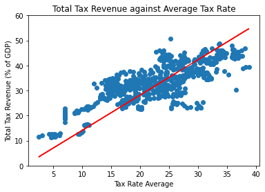

```python
generate_scatter(data['Total Tax Revenue'], "Total Tax Revenue")
```

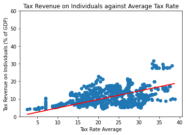

```python
generate_scatter(data['Tax Revenue on Individuals'], "Tax Revenue on Individuals")
```

As we can see, these two plots clearly show a positive correlation between the tax revenue and tax rate, as can be seen with the positive slope of both linear regressions. Moreover, since the range of tax rate average is less than 40, it should not be the case that a negative correlation appears. Additionally, particularly in the first plot of total tax revenue, it does appear that there is some sort of diminishing marginal effect of tax rate, as many of the data points on the left end of the distribution appear above the regression line, but many of the points on the right end appear below it.

While the trends that we expected to see in the Laffer curve have been verified by this initial data analysis, there is also the issue of any possible correlation between year and tax revenue. While the relationship between tax revenue and rate shown in the Laffer curve is intended to reflect the actual effect of tax rate on other variables, such as labor supply or entrepreneurship, any correlation between the year and tax revenue may convolude the effect that we are interested in. To deal with this potential issue, we must first analyze the distribution of tax revenues by year.

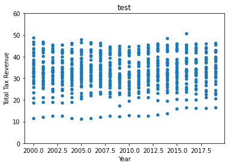

```python
data.plot(x='Year', y='Total Tax Revenue', kind='scatter', title="test", ylim=[0,60])
```

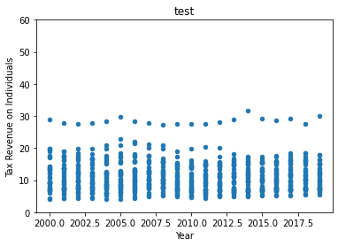

```python
data.plot(x='Year', y='Tax Revenue on Individuals', kind='scatter', title="test", ylim=[0,60])
```

By plotting the total and individual tax revenue against year for the dataset, we can see the distributions of each revenue by year. These plots show us that tax revenue is relatively uniformly distributed with respect to the year. This is very reassuring to our previous concern. Since the distributions are approximately the same for each year, and because there are no trends in the plotted data, we can safely assume that there is little to no correlation between tax revenue and year that could be influencing our analysis.

## Machine Learning

While some exploratory analysis has verified the initial positive correlation implied by the Laffer curve, in addition to confirming that there is no need to standardize our tax revenues by year, to actually generate a model of the Laffer curve, we will need to utilize machine learning. Specifically, we will be using sklearn to implement a nonlinear regression, and test different degrees of a polynomial regression, using a portion of the tax data for training each model and a portion for testing it. Once we have done this, we will also want to analyze the results of the various regressions to see which is a best estimate for the Laffer curve, without overfitting to the data and while minimizing the complexity of the model. For this analysis, we will only be using the total tax revenue data, as running the nonlinear regressions on individual tax revenues has a similar result.

```python
# this chunk of code supresses warnings stemming from the step size of the sklearn model generation
def warn(*args, **kwargs):
    pass
import warnings
warnings.warn = warn

# imports necessary for the machine learning nonlinear model generation/testing
import numpy as np
from sklearn.model_selection import train_test_split
from sklearn.preprocessing import PolynomialFeatures
from sklearn.linear_model import LassoCV
from sklearn.pipeline import make_pipeline
```

```python
# arrays used to store data about each polynomial degree model for later analysis
model_degree = []
model_lst = []
RMSE_lst = []
test_score_lst = []

# some of the following code was sourced from Towards Data Science (specifically LASSO values and make_pipeline code)
# Alpha (regularization strength) of LASSO regression
lasso_eps = 0.0001
lasso_nalpha=20
lasso_iter=5000
# the range of polynomial degree for which to generate regressions
degree_min = 1
degree_max = 8
# division of training and testing data
test_set_fraction = 0.2
X_train, X_test, y_train, y_test = train_test_split(data['Rate Average'], data['Total Tax Revenue'],test_size=test_set_fraction)

# adjusts shape of these arrays for use in fitting the models in the next step
X_train = X_train.values.reshape(-1,1)
X_test = X_test.values.reshape(-1,1)

# Make a pipeline model with polynomial transformation and LASSO regression with cross-validation, run it for increasing degree of polynomial (complexity of the model)
for degree in range(degree_min,degree_max+1):
    model = make_pipeline(PolynomialFeatures(degree, interaction_only=False), LassoCV(eps=lasso_eps,n_alphas=lasso_nalpha,max_iter=lasso_iter,
normalize=True,cv=5,  fit_intercept = False))
    model.fit(X_train,y_train)
    test_pred = np.array(model.predict(X_test))
    RMSE=np.sqrt(np.sum(np.square(test_pred-y_test)))
    test_score = model.score(X_test,y_test)

    model_degree.append(degree)
    model_lst.append(model)
    RMSE_lst.append(RMSE)
    test_score_lst.append(test_score)
```

Now that we have non-linear models, with polynomial degree ranging from 1 to 8, we need to determine which model best is the best estimate for the Laffer curve. We can do this by plotting the progression of the Root Mean Square Error (RMSE) and the R-Squared values resulting from the test data as the degree of the model was increased.

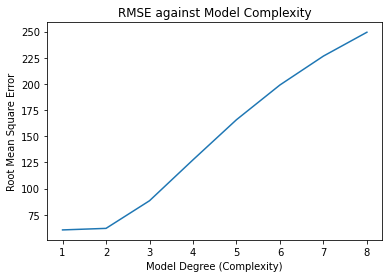

```python
plt.plot(model_degree, RMSE_lst)
plt.xlabel('Model Degree (Complexity)')
plt.ylabel('Root Mean Square Error')
plt.title('RMSE against Model Complexity')
```

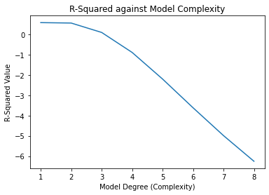

```python
plt.plot(model_degree, test_score_lst)
plt.xlabel('Model Degree (Complexity)')
plt.ylabel('R-Squared Value')
plt.title('R-Squared against Model Complexity')
```

More information about how to perform nonlinear regressions using machine learning can be found at https://towardsdatascience.com/machine-learning-with-python-easy-and-robust-method-to-fit-nonlinear-data-19e8a1ddbd49.

## Conclusions

Now that we have run our polynomial regressions for tax revenue on tax rate, we can come to some conclusions about our analysis relative to the Laffer curve. To start, while the polynomial regressions did not show significant difference between the simple and the quadratic regressions, the quadratic is much more useful in modeling the curve because it is capable of capturing the curve's return to zero. Moreover, we were able to see that our model of the Laffer curve should not have more than two degrees, as the R-squared rapidly began to fall, and the RMSE rapidly began to rise. Now, we can graph the two degree polynomial regression with the data.

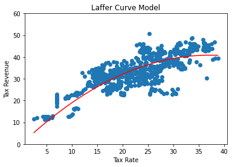

```python
plt.scatter(data['Rate Average'], data['Total Tax Revenue'])
plt.xlabel('Tax Rate')
plt.ylabel('Tax Revenue')
plt.title('Laffer Curve Model')
plt.ylim([0, 60])
sorted_data = [i for i in data['Rate Average']]
sorted_data.sort()
ind = [[i] for i in sorted_data] # formatting for regression
plt.plot(ind, model_lst[1].predict(ind), color='red')
```

With respect to this model, it appears that the Laffer curve' maximum appears at around a 40 percent tax rate. This does not line up with established estimates, which put the peak at 60-70 percent. However, it is important to keep in mind that our model of the Laffer curve only models the effect of tax rate on tax revenue for countries in the OECD, and not all countries around the globe. Countries in the OECD tend to be economically developed with relatively liberal and democratic governments, and these factors could alter degree to which tax rate affects tax revenue. Moreover, previous economic estimates of the curve may have controlled for other factors and influences, whereas ours relied on the simple relationship between the rate and revenue, after assuring that we need not standardize by year. Additionally, this lower tax rate peak may have occurred because, unlike how we were able to force the regressions through the origin, we are not able to force it through the point representing a tax rate of 100 percent and revenue of zero, as doing so may require a more complex model than we can generate using polynomial regression.

While this tutorial may have fallen short of replicating previous estimates of the Laffer curve, I hope that it leaves you more informed on the data science process and given you insight into its application.